# Δημιουργία εκπαιδευτικού υλικού για την εκμάθηση της γλώσσας προγραμματισμού R

## R - Γραμμική παλινδρόμηση - R Linear Regression

Η ανάλυση παλινδρόμησης είναι ένα πολύ ευρέως χρησιμοποιούμενο στατιστικό εργαλείο για τη δημιουργία ενός μοντέλου σχέσης μεταξύ δύο μεταβλητών. Μία από αυτές τις μεταβλητές ονομάζεται μεταβλητή πρόβλεψης της οποίας η τιμή συλλέγεται μέσω πειραμάτων. Η άλλη μεταβλητή ονομάζεται μεταβλητή απόκρισης της οποίας η τιμή προέρχεται από τη μεταβλητή πρόβλεψης.

Η γενική μαθηματική εξίσωση για μια γραμμική παλινδρόμηση είναι `y = ax + b` Όπου :

y είναι η μεταβλητή απόκρισης.

x είναι η μεταβλητή πρόβλεψης.

a και b είναι σταθερές που ονομάζονται συντελεστές.

**Παράδειγμα** Ένα απλό παράδειγμα παλινδρόμησης είναι η πρόβλεψη του βάρους ενός ατόμου όταν το ύψος του είναι γνωστό. Για να γίνει αυτό πρέπει να έχουμε τη σχέση μεταξύ ύψους και βάρους ενός ατόμου.

```r
# Δεδομένα υψους
x <- c(151, 174, 138, 186, 128, 136, 179, 163, 152, 131)

# Δεδομένα Βάρους
y <- c(63, 81, 56, 91, 47, 57, 76, 72, 62, 48)

# Δημιουργία συσχέτισης μέσω της συνάρτησης lm()
sxesi <- lm(y~x)
```

Η συνάρτηση lm() Linear Regration δημιουργεί ένα απλο μοντέλο παλιδρόμησης της μορφής `y = ax + b` https://www.r-bloggers.com/2009/11/r-tutorial-series-simple-linear-regression/

Στη συνέχεια μπορούμε να προβλέψουμε το βάρος `y` δίνοντας οποιοδήποτε ύψος `x` . Για την πρόβλεψη χρησιμοποιούμε την συνάρτηση predict() όπως παρακάτω :

```r
a <- data.frame(x = 170)
result <-  predict(sxesi,a)
print(result)
```

```
       1
76.22869
```

**Γραφική παράσταση**

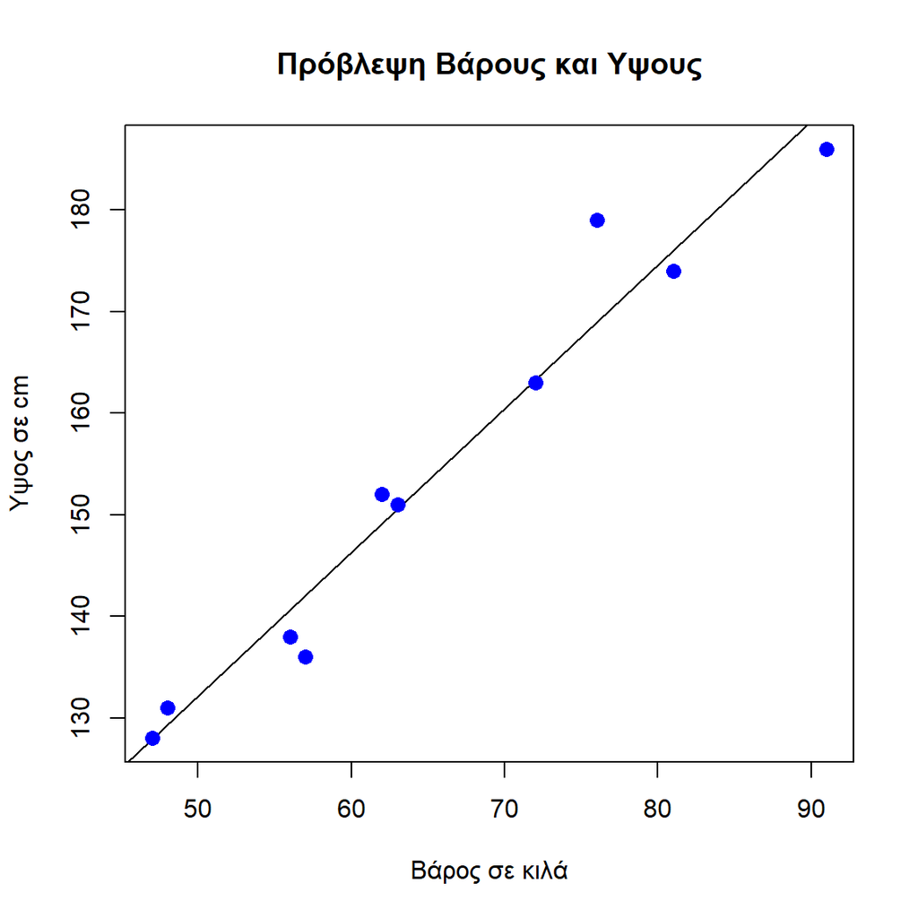

```r
x <- c(151, 174, 138, 186, 128, 136, 179, 163, 152, 131)
y <- c(63, 81, 56, 91, 47, 57, 76, 72, 62, 48)
relation <- lm(y~x)
plot(y,x,col = "blue",main = "Πρόβλεψη Βάρους και Υψους",
abline(lm(x~y)),cex = 1.3,pch = 16,xlab = "Βάρος σε κιλά",ylab = "Υψος σε cm")
```

Με τη ggplot στο ίδιο παράδειγμα αρκεί να δημιουργήσουμε ένα data.frame με τα δεδομένα μας.

[figure not shown]

```r
x <- c(151, 174, 138, 186, 128, 136, 179, 163, 152, 131)
y <- c(63, 81, 56, 91, 47, 57, 76, 72, 62, 48)
mydata <- data.frame("x" = x, "y" = y, "Name" = c("x","y"))
ggplot(mydata,aes(x,y))+
     geom_point()+
     geom_smooth(method = "lm")+
     ggtitle("Πρόβλεψη Βάρους και ύψους") + ylab("Υψος σε cm")+ xlab("Βάρος σε κιλά")
```

## R - Κανονική κατανομή

Η R έχει τέσσερις ενσωματωμένες λειτουργίες για τη δημιουργία κανονικής κατανομής.

dnorm(x, mean, sd) pnorm(x, mean, sd) qnorm(p, mean, sd) rnorm(n, mean, sd)

Ακολουθεί η περιγραφή των παραμέτρων που χρησιμοποιούνται στις παραπάνω συναρτήσεις :

Το x είναι ένα διάνυσμα αριθμών.

Το p είναι ένα διάνυσμα πιθανοτήτων.

n είναι ο αριθμός των παρατηρήσεων (μέγεθος δείγματος).

Το `mean` είναι η μέση τιμή του δείγματος δεδομένων, με defalt τιμή το μηδέν.

Το `sd` είναι η τυπική απόκλιση, με defalt τιμή το 1.

**`dnorm ()`** Αυτή η συνάρτηση δίνει το ύψος της κατανομής της πιθανότητας σε κάθε σημείο για μια δεδομένη μέση και τυπική απόκλιση.

**Παράδειγμα**

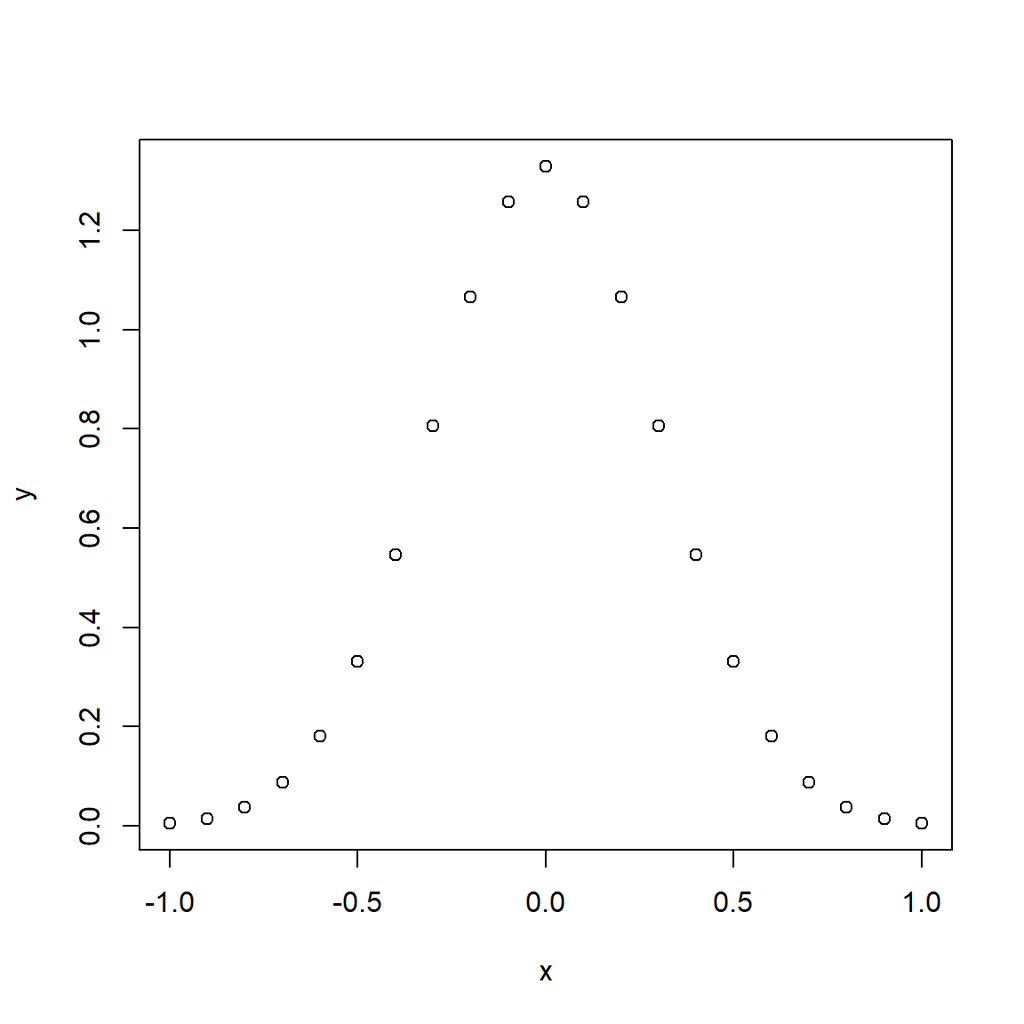

```r
# Δημιουργούμε μια ακολουθία αριθμών από το -1 ως το 1 με απόσταση μεταξύ τους 0.1
x <- seq(-1, 1, by = .1)

# Επιλέγουμε την μέση τιμή στo 0 και τυπική απόκλιση 0,3.
y <- dnorm(x, mean = 0, sd = 0.3)

# Σχεδιάζουμε το ύψος της κατανομής
plot(x,y)
```

**`pnorm ()`** Αυτή η συνάρτηση δίχνει την πιθανότητα ενός κανονικά κατανεμημένου τυχαίου αριθμού να είναι μικρότερη από την τιμή ενός δεδομένου αριθμού. Ονομάζεται επίσης “Λειτουργία αθροιστικής διανομής”.

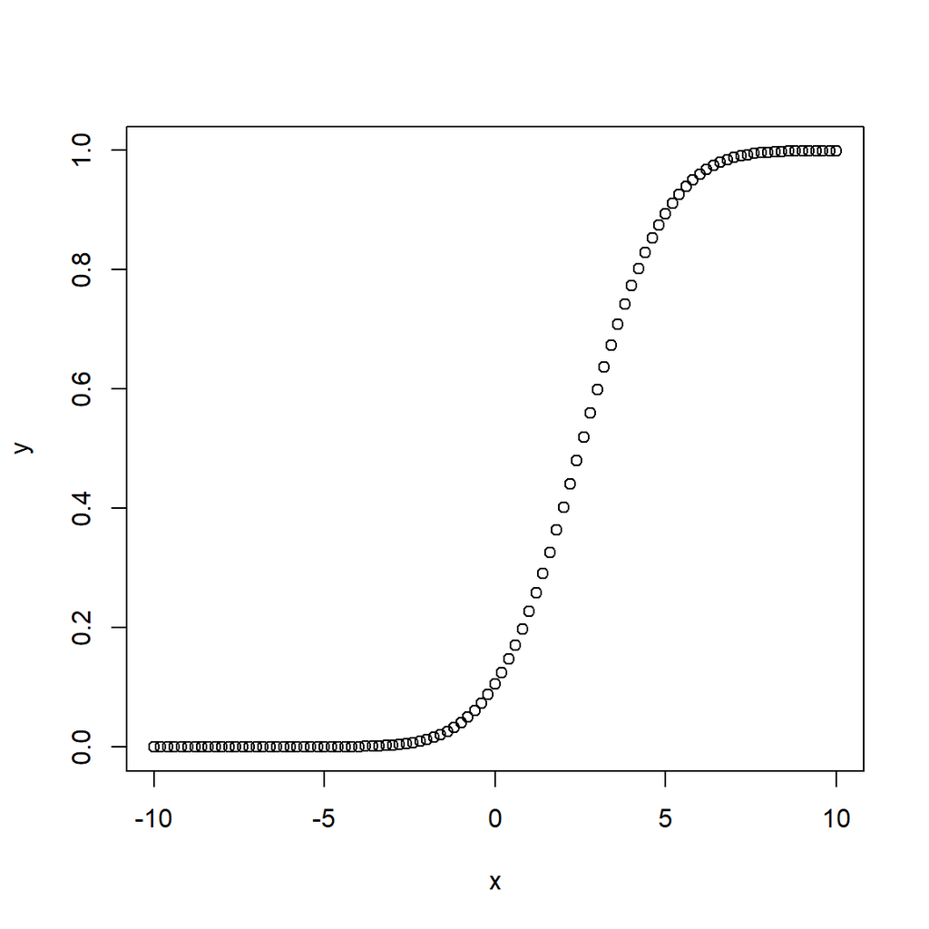

```r
# Δημιουργούμε μια ακολουθία αριθμών από το -10 ως το 10 με απόσταση μεταξύ τους 0.2
x <- seq(-10,10,by = .2)

# Επιλέγουμε την μέση τιμή στo 2.5 και τυπική απόκλιση 2.
y <- pnorm(x, mean = 2.5, sd = 2)

# Σχεδιάζουμε το ύψος της κατανομής
plot(x,y)
```

**`qnorm ()`** Αυτή η συνάρτηση λαμβάνει την τιμή πιθανότητας και δίνει έναν αριθμό του οποίου η αθροιστική τιμή ταιριάζει με την τιμή πιθανότητας.

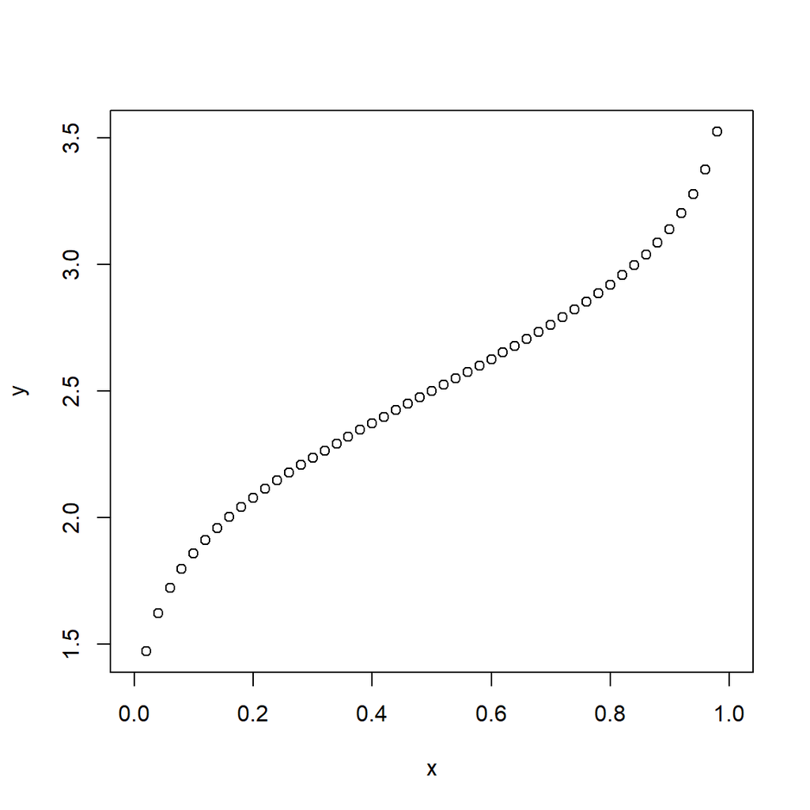

```r
# Δημιουργούμε μια ακολουθία αριθμών από το 0 ως 1 με απόσταση μεταξύ τους 0.02
x <- seq(0, 1, by = 0.02)

# Επιλέγουμε μέση τιμή 2.5 και τυπική απόκλιση 0.5.
y <- qnorm(x, mean = 2.5, sd = 0.5)


# Σχεδιάζουμε το ύψος της κατανομής
plot(x,y)
```

**`rnorm ()`** Αυτή η συνάρτηση χρησιμοποιείται για τη δημιουργία τυχαίων αριθμών των οποίων η κατανομή είναι φυσιολογική. Παίρνει το μέγεθος του δείγματος ως είσοδο και δημιουργεί πολλούς τυχαίους αριθμούς. Σχεδιάζουμε ένα ιστόγραμμα για να δείξουμε την κατανομή των παραγόμενων αριθμών.

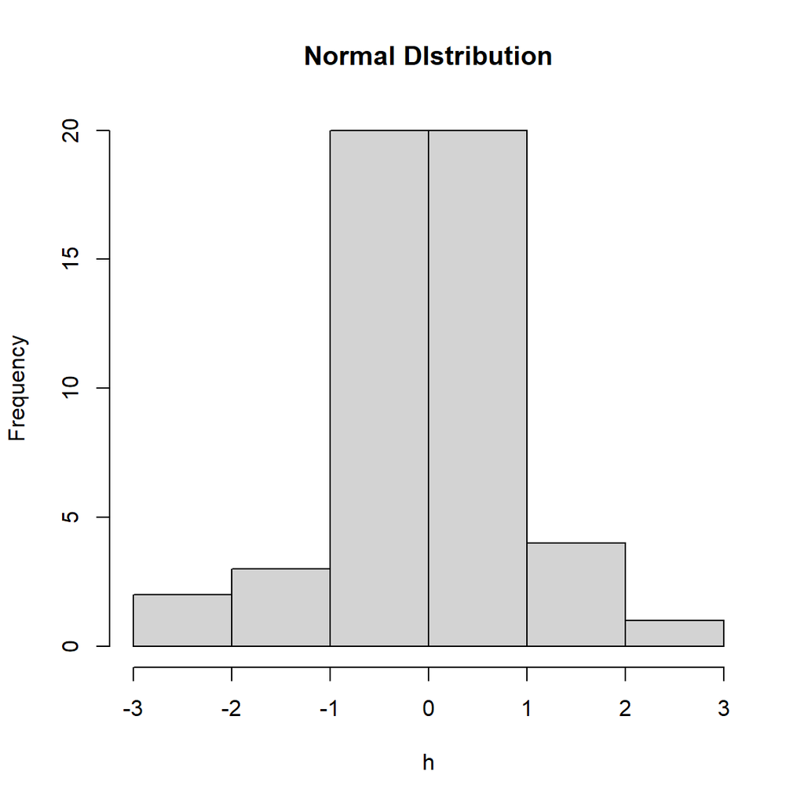

```r
# Create a sample of 50 numbers which are normally distributed.
h <- rnorm(50)
# Plot the histogram for this sample.
hist(h, main = "Normal DIstribution")
```

Ας δούμε το αντίστοιχο παράδειγμα με τη χρήση της ggplot : http://rstudio-pubs-static.s3.amazonaws.com/374857_5a23bad9783a43c1b102aa80aa5c1a7c.html

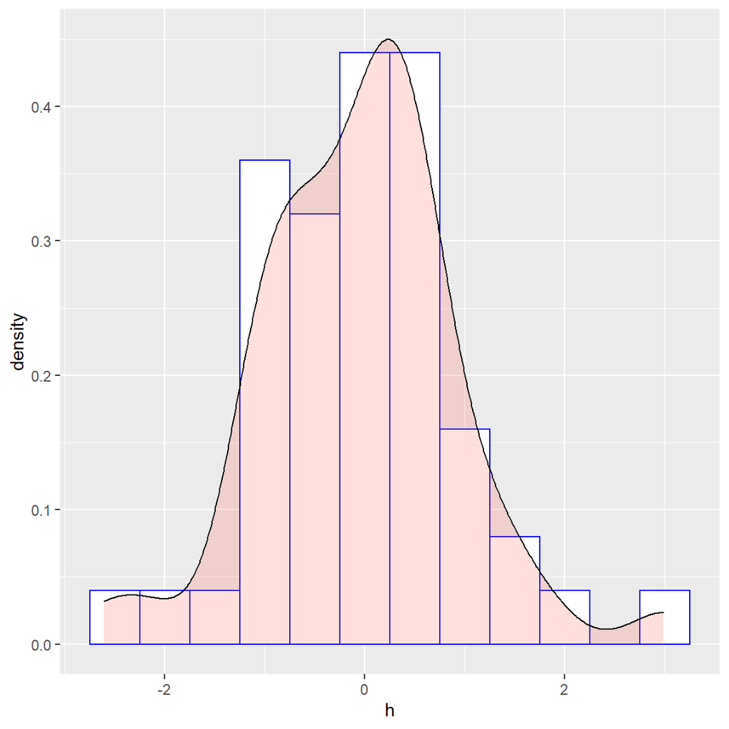

```r
data<-data.frame("x"=h)
ggplot(data, aes(x = h)) +
  geom_histogram(aes(y = ..density..), # Το Ιστόγραμμα θα εμφανίζει την πυκνότητα στον y-axis
                 binwidth = .5, colour = "blue", fill = "white") +
  geom_density(alpha = .2, fill="#FF6655") # Επικάλυψη με διαφάνεια της πυκνότητας
```

## R - Δέντρο απόφασης

Το δέντρο αποφάσεων είναι ένα γράφημα που αντιπροσωπεύει τις επιλογές και τα αποτελέσματά τους σε μορφή δέντρου. Οι κόμβοι στο γράφημα αντιπροσωπεύουν ένα συμβάν ή επιλογή και τα άκρα του γραφήματος αντιπροσωπεύουν τους κανόνες ή τις προϋποθέσεις απόφασης. Χρησιμοποιείται κυρίως σε εφαρμογές Μηχανικής Μάθησης και Εξόρυξης Δεδομένων χρησιμοποιώντας R.

Παραδείγματα χρήσης του τρόπου λήψης αποφάσεων είναι - η πρόβλεψη ενός μηνύματος ηλεκτρονικού ταχυδρομείου ως ανεπιθύμητου ή μη ανεπιθύμητου, η πρόβλεψη ενός όγκου είναι καρκινική ή η πρόβλεψη ενός δανείου ως καλό ή κακό πιστωτικό κίνδυνο με βάση τους παράγοντες σε καθένα από αυτά. Γενικά, δημιουργείται ένα μοντέλο με παρατηρούμενα δεδομένα που ονομάζονται επίσης δεδομένα εκπαίδευσης. Στη συνέχεια χρησιμοποιείται ένα σύνολο δεδομένων επικύρωσης για την επαλήθευση και τη βελτίωση του μοντέλου. Η R έχει πακέτα που χρησιμοποιούνται για τη δημιουργία και την απεικόνιση δέντρων αποφάσεων. Για νέο σύνολο μεταβλητής πρόβλεψης, χρησιμοποιούμε αυτό το μοντέλο για να λάβουμε μια απόφαση σχετικά με την κατηγορία (ναι / Όχι) των δεδομένων.

Το πακέτο `party` χρησιμοποιείται για τη δημιουργία δένδρων αποφάσεων. Αρχικά θα πρέπει να εγκαταστήσουμε το πακέτο

[output not shown]

Το πακέτο “party” έχει τη συνάρτηση `ctree ()` που χρησιμοποιείται για τη δημιουργία και την ανάλυση του δέντρου decison.

Η βασική σύνταξη για τη δημιουργία ενός δέντρου αποφάσεων στο R είναι `ctree(formula, data)`

**Παράδειγμα** Χρησιμοποιούμε δεδομένα του dataset readingSkills

```r
print(head(readingSkills))
```

```
  nativeSpeaker age shoeSize    score
1           yes   5 24.83189 32.29385
2           yes   6 25.95238 36.63105
3            no  11 30.42170 49.60593
4           yes   7 28.66450 40.28456
5           yes  11 31.88207 55.46085
6           yes  10 30.07843 52.83124
```

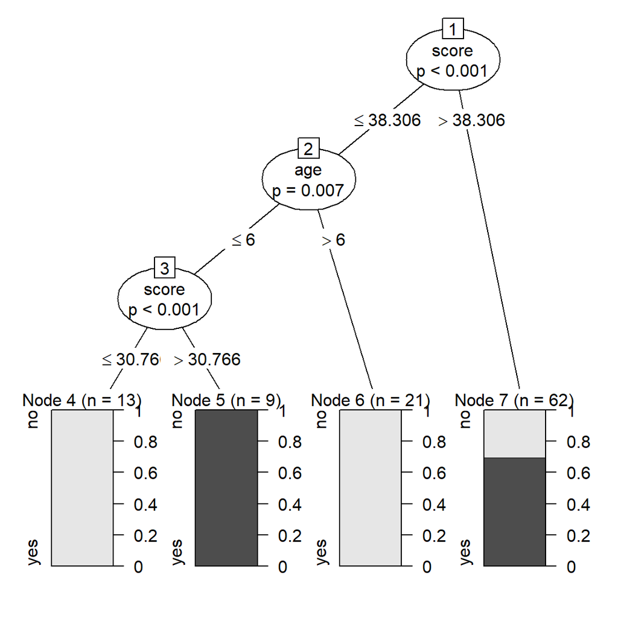

```r
# Μεταφέρουμε δεδομένα σε ένα data.frame
Newdata <- readingSkills[c(1:105),]

# Δημιουργούμε ένα δένδρο
  mytree <- ctree(nativeSpeaker ~ age + shoeSize + score,
  data =Newdata)

# Plot the tree.
plot(mytree)
```

Από το δέντρο αποφάσεων που φαίνεται παραπάνω μπορούμε να συμπεράνουμε ότι όποιος έχει σκόρ μικρότερο από 38,3 και η ηλικία είναι άνω των 6 δεν είναι εγγενής ομιλητής.

```r
# Modeling packages
library(rpart)       # Αυτόματη μηχανή για δημιουργία δέντρων απόφασης
library(rpart.plot)  # Σχεδιασμός δέντρων αποφάσεων
```

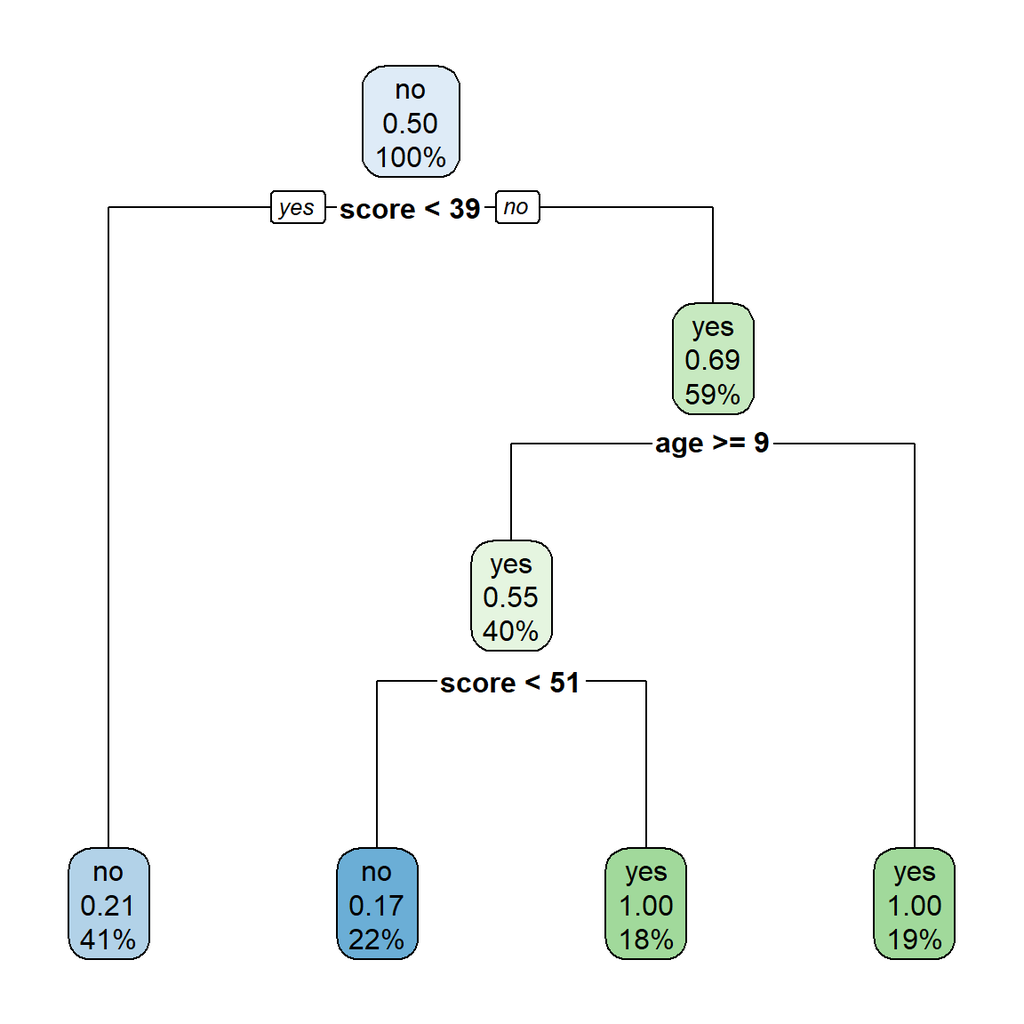

```r
fit <- rpart(nativeSpeaker ~ age + shoeSize + score,
  data =Newdata)
rpart.plot(fit)
```

# Μάθημα 10ο - R Markdown

## Markdown

[video not shown]

**Τι είναι το Markdown;** Το Markdown είναι μια μορφή απλού κειμένου για τη σύνταξη δομημένων εγγράφων, βάσει συμβάσεων μορφοποίησης από email και usenet. Αναπτύχθηκε το 2004 από τον John Gruber σε συνεργασία με τον Aaron Swartz . Ο Gruber έγραψε τον πρώτο μετατροπέα markdown-to-html σε Perl και σύντομα χρησιμοποιήθηκε ευρέως σε ιστότοπους

Το **R Markdown** παρέχει ένα ενοποιημένο πλαίσιο σύνταξης για την επιστήμη των δεδομένων, συνδυάζοντας στον κώδικά σας, τα αποτελέσματά του και τον σχολιασμό. Τα έγγραφα R Markdown είναι αναπαραγώγιμα και υποστηρίζουν δεκάδες μορφές εξόδου, όπως PDF, αρχεία Word, προβολές διαφανειών και άλλα.

**Βασικά στοιχεία του Markdown**

Αυτό είναι ένα αρχείο R Markdown, απλού κειμένου που έχει την επέκταση .Rmd, περιέχει τρεις σημαντικούς τύπους περιεχομένου:

- Μια (προαιρετική) κεφαλίδα YAML που περιβάλλεται από —.
- Κομμάτια του κώδικα R που περιβάλλεται από ```.
- Κείμενο που αναμιγνύεται με απλή μορφοποίηση κειμένου όπως # heading και *italics*.

Όταν ανοίγετε ένα .Rmd, λαμβάνετε μια διεπαφή σημειωματάριου όπου ο κώδικας και η έξοδος αλληλοεμπλέκονται. Μπορείτε να εκτελέσετε κάθε κομμάτι κώδικα κάνοντας κλικ στο εικονίδιο Εκτέλεση (μοιάζει με κουμπί αναπαραγωγής στο πάνω μέρος του κώδικα) ή πατώντας Ctrl + Shift + Enter. Το RStudio εκτελεί τον κώδικα και εμφανίζει τα αποτελέσματα.

Για να δημιουργήσετε μια πλήρη αναφορά που περιέχει όλο το κείμενο, τον κώδικα και τα αποτελέσματα, κάντε κλικ στο κουμπί “Knit” ή πατήστε Ctrl + Shift + K. Μπορείτε επίσης να το κάνετε αυτό μέσω προγραμματισμού rmarkdown::render(“1-example.Rmd”). Αυτό θα εμφανίσει την αναφορά στο παράθυρο προβολής και θα δημιουργήσει ένα αυτόνομο αρχείο που μπορείτε να μοιραστείτε με άλλους.

Όταν δημιουργείται το έγγραφο, το R Markdown στέλνει το αρχείο .Rmd στο knitr , http://yihui.name/knitr/ , το οποίο εκτελεί όλα τα κομμάτια κώδικα και δημιουργεί ένα νέο έγγραφο markdown (.md) που περιλαμβάνει τον κώδικα και το κείμενο. Στη συνέχεια, το αρχείο markdown που δημιουργείται από το knitr υποβάλλεται σε επεξεργασία από το pandoc , http://pandoc.org/ , το οποίο είναι υπεύθυνο για τη δημιουργία του τελικού αρχείου. Το πλεονέκτημα αυτής της ροής εργασιών είναι ότι μπορείτε να δημιουργήσετε ένα πολύ ευρύ φάσμα μορφών εξόδου.

Για να ξεκινήσετε με το δικό σας .Rmd αρχείο, επιλέξτε Αρχείο => Νέο αρχείο R Markdow στο μενού. Το RStudio θα ξεκινήσει έναν οδηγό που μπορείτε να χρησιμοποιήσετε για να συμπληρώσετε το αρχείο σας με περιεχόμενο που σας υπενθυμίζει πώς λειτουργούν τα βασικά χαρακτηριστικά του R Markdown.

Για την συγγραφή ολοκληρωμένων συγγεραμμάτων με R Μarkdown είναι χρήσιμο να χρησιμοποιείται cheat Sheet όπως το http://datascience.maths.unitn.it/events/reaction2017/day1/Cheatsheets/rmarkdown-cheatsheet-2.0.pdf.

**Βιβλιογραφίες και παραπομπές** Το Pandoc μπορείτε να δημιουργήσετε αυτόματα παραπομπές και βιβλιογραφία σε διάφορα στυλ. Για να χρησιμοποιήσετε αυτήν τη δυνατότητα, καθορίστε ένα αρχείο βιβλιογραφίας χρησιμοποιώντας το `bibliography` πεδίο στην κεφαλίδα του αρχείου σας. Το πεδίο πρέπει να περιέχει μια διαδρομή από τον κατάλογο που περιέχει το αρχείο .Rmd στο αρχείο που περιέχει το αρχείο βιβλιογραφίας:

`bibliography: rmarkdown.bib`

Για να δημιουργήσετε μια αναφορά μέσα στο αρχείο .Rmd, χρησιμοποιήστε ένα κλειδί που αποτελείται από το «@» + το αναγνωριστικό παραπομπής από το αρχείο βιβλιογραφίας. Στη συνέχεια, τοποθετήστε την αναφορά σε αγκύλες. Ορίστε μερικά παραδείγματα:

`` Διαχωρίστε με ερωτηματικό `;` διπλές αναφορές οπώς [@αναφορά1; @αναφορά2]. `` `Μπορείτε να προσθέσετε σχόλια εντός των αγκίστρων όπως [βλέπε @αναφορά1; επίσης @αναφορά2].` `Μπορείτε να συμπεριλάβετε μια αναφροά εντός του κειμένου σας χωρίς άγκιστρο απ' ευθείας με @αναφορά1.`

Το R Markdown, θα προσθέσει μια βιβλιογραφία στο τέλος του εγγράφου σας. Η βιβλιογραφία θα περιέχει κάθε μία από τις αναφερόμενες αναφορές από το αρχείο βιβλιογραφίας, αλλά δεν θα περιέχει επικεφαλίδα ενότητας. Ως αποτέλεσμα, είναι κοινή πρακτική να τερματίζετε το αρχείο σας με μια κεφαλίδα ενότητας για τη βιβλιογραφία, όπως #References ή #Βιβλιογραφία.

[output not shown]

# Quiz

## Quiz 1

# Βιβλιογραφία

**Ελληνόγλωσση βιβλιογραφία**  
- Φωκιανός & Χαραλάμπους, (2010). Εισαγωγή στην R Πρόχειρες Σημειώσεις Τμήμα Μαθηματικών και Στατιστικής Πανεπιστήμιου Κύπρου 2η έκδοση

- - Βερύκιος Σ Βασίλειος, Καγκλής Βασίλειος, Σταυρόπουλος Κ. Ηλίας, (2015). Η επιστήμη των δεδομένων μέσα από τη γλώσσα R

**Ξενόγλωσση Βιβλιογραφία**  
- Roger D. Peng, (2015). R Programming for Data Science  
- Becker, R. A., Chambers, J. M. and Wilks, A. R. (1988), The New S Language.  
- Maechler Martin Seminar fur statistic https://stat.ethz.ch/R-manual/  
- Yihui Xie, JJ Allaire, Garrett Grolemund, (2021) R Markdown: The Definitive Guide (https://bookdown.org/yihui/rmarkdown/)  
- Barnier, Julien. 2021.Rmdformats: HTML Output Formats and Templates for Rmarkdown Documents.https://github.com/juba/rmdformats.

**Διαδίκτυο**  
- OBS Studio https://obsproject.com/download  
- https://en.wikipedia.org/wiki/R_(programming_language) R programming language, (2021)  
- http://rstudio.cloud  
- https://www.tutorialspoint.com/r/index.htm  
- http://www.sthda.com/english/wiki/r-xlsx-package-a-quick-start-guide-to-manipulate-excel-files-in-r ,2019  
- https://r4ds.had.co.nz/data-visualisation.html ,2018  
- https://r4ds.had.co.nz/transform.html  
- https://www.tutorialspoint.com/r/r_mean_median_mode.htm  
- http://rstudio-pubs-static.s3.amazonaws.com/374857_5a23bad9783a43c1b102aa80aa5c1a7c.html,2020  
- https://www.investopedia.com/terms/m/median.asp , 2019)  
- https://www.r-bloggers.com/2009/11/r-tutorial-series-simple-linear-regression/